# TXSScan

Sander Wuyts

31 August 2018

# First glimpse

How many hits per genome?

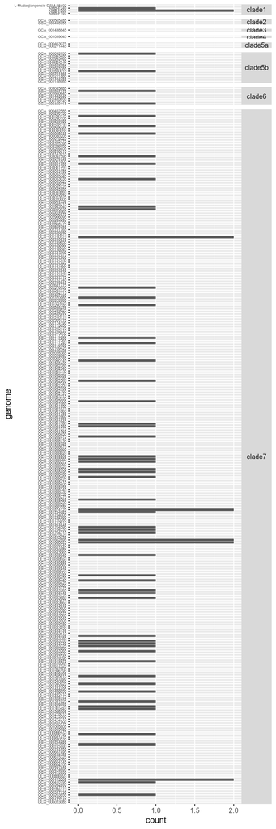

```r
TXSScan_count %>%
  ggplot(aes(x = genome, y = count)) +
  geom_col() +
  facet_grid(cladeNumber_split~., scales = "free_y", space = "free_y") +
  coord_flip() +
  theme(strip.text.y =  element_text(angle = 0),
        axis.text.y = element_text(size = 5))
```

Hits can only be found in clade 1, 5b, 6 and clade 7. In 6 genomes in total, 2 copies are found. This is a small difference compared with our previous analysis. Maybe due to better assembly?

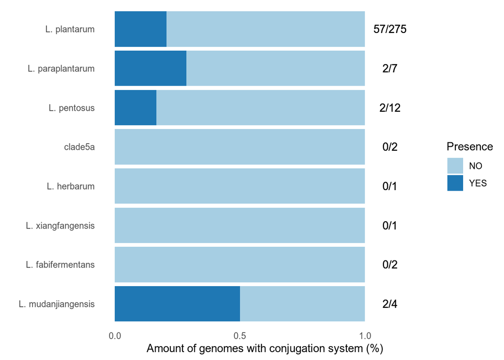

```r
TXSScan_count %>%
  group_by(cladeName) %>%
  mutate(genomesPerClade = genome %>% unique() %>% length()) %>%
  ungroup() %>%
  mutate(presence = if_else(count > 0, 1, 0)) %>%
  select(-count) %>%
  distinct() %>%
  group_by(cladeName) %>%
  summarise(count = sum(presence), numberOfGenomes = unique(genomesPerClade), YES = sum(presence/genomesPerClade), NO = 1-sum(presence/genomesPerClade)) %>%
  ungroup() %>%
  mutate(number_label = str_c(count, "/", numberOfGenomes)) %>%
  select(-count, -numberOfGenomes) %>%
  gather(key = "Presence", value = "relabun", - cladeName, -number_label) %>%
  mutate(cladeName = factor(cladeName, levels = c("L. mudanjiangensis",
                                                  "L. fabifermentans",
                                                  "L. xiangfangensis",
                                                  "L. herbarum",
                                                  "clade5a",
                                                  "L. pentosus",
                                                  "L. paraplantarum",
                                                  "L. plantarum"))) %>%
  ggplot(aes(x = cladeName, y = relabun, fill = Presence)) +
  geom_col() +
  geom_text(aes(y = 1.1, label = number_label)) +
  expand_limits(y = 1.2) +
  scale_y_continuous(breaks = c(0, 0.5, 1)) +
  coord_flip() +
  scale_fill_brewer(palette = "Paired") +
  theme_minimal() +
  theme(panel.grid = element_blank()) +
  xlab("") +
  ylab("Amount of genomes with conjugation system (%)")
```

Some summarised info

```r
TXSScan_count %>%
  group_by(cladeNumber_split) %>%
  mutate(genomesPerClade = genome %>% unique() %>% length()) %>%
  ungroup() %>%
  mutate(presence = if_else(count > 0, 1, 0)) %>%
  filter(presence > 0) %>%
  select(-count) %>%
  distinct() %>%
  group_by(cladeNumber_split) %>%
  summarise(count = sum(presence), numberOfGenomes = unique(genomesPerClade), rel_abundance = sum(presence/genomesPerClade))
```

```
## # A tibble: 4 x 4
##   cladeNumber_split count numberOfGenomes rel_abundance
##   <chr>             <dbl>           <int>         <dbl>
## 1 clade1                2               4         0.5
## 2 clade5b               2              12         0.167
## 3 clade6                2               7         0.286
## 4 clade7               57             275         0.207
```

What systems are found?

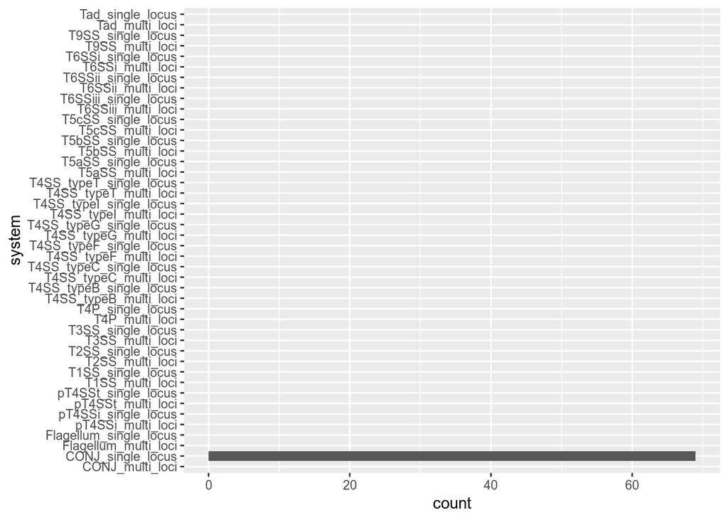

```r
TXSScan_count %>%
  group_by(system) %>%
  summarise(count = sum(count)) %>%
  ggplot(aes(x = system, y = count)) +
  geom_col() +
  coord_flip()
```

All of them are found in the same category. I wonder whether this is also true for rest of Lactobacilli.

# More in depth

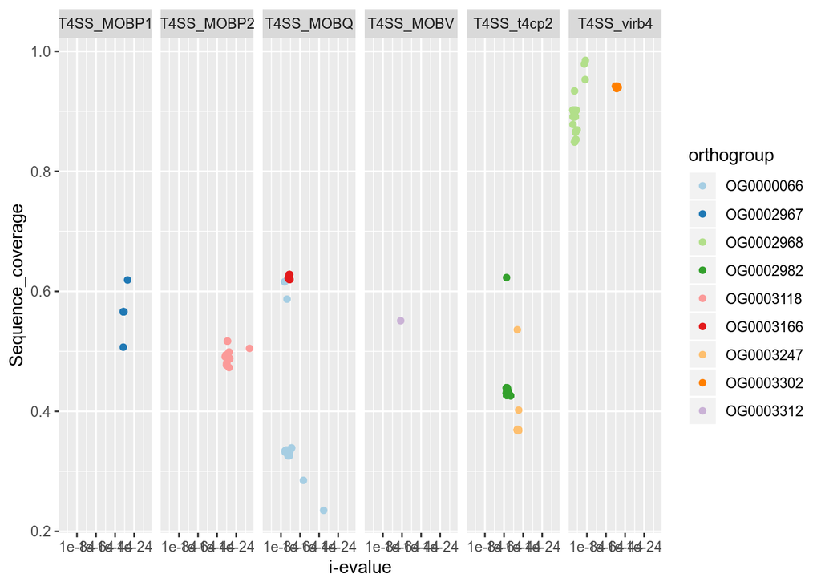

```r
TXSScan_genes %>%
  ggplot(aes(x = `i-evalue`, y = Sequence_coverage, colour = orthogroup)) +
  geom_point() +
  facet_grid(~Gene) +
  scale_x_log10() +
  scale_colour_brewer(palette = "Paired")
```

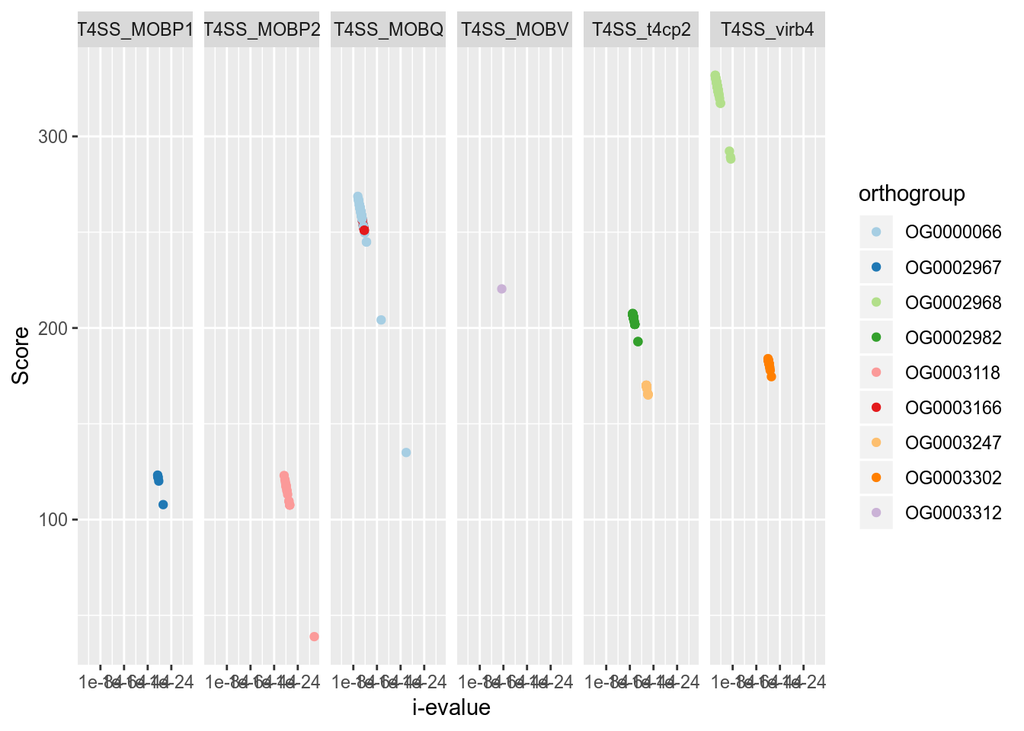

```r
TXSScan_genes %>%
  ggplot(aes(x = `i-evalue`, y = Score, colour = orthogroup)) +
  geom_point() +
  facet_grid(~Gene) +
  scale_x_log10() +
  scale_colour_brewer(palette = "Paired")
```

General hits

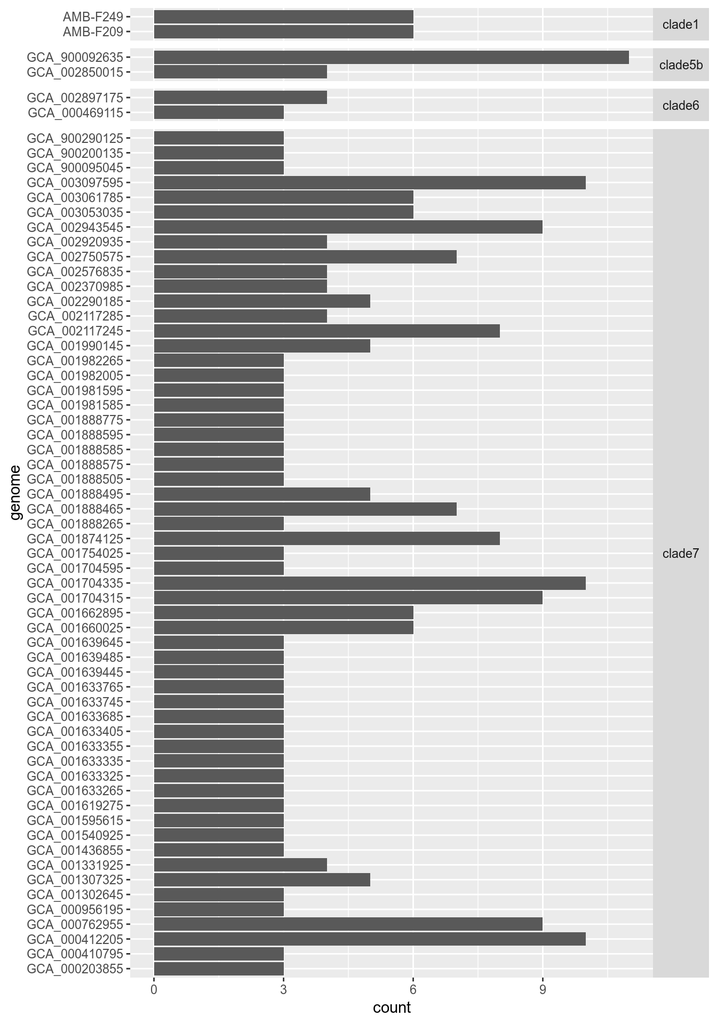

```r
TXSScan_genes %>%
  group_by(genome, cladeNumber_split) %>%
  summarise(count = n()) %>%
  ggplot(aes(x = genome, y = count)) +
  geom_col() +
  facet_grid(cladeNumber_split~., scales = "free_y", space = "free_y") +
  coord_flip() +
  theme(strip.text.y =  element_text(angle = 0))
```

Cool, not every genome seems to be having hits, and definitely not the same amount of hits. Let’s colour this graph based on the database hits

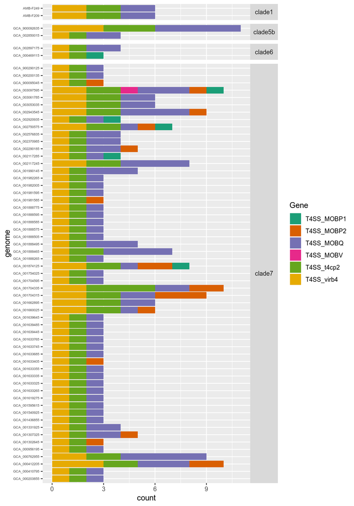

```r
TXSScan_genes %>%
  ggplot(aes(x = genome, fill = Gene)) +
  geom_bar() +
  coord_flip() +
  scale_fill_brewer(palette = "Dark2") +
  facet_grid(cladeNumber_split~., scales = "free_y", space = "free_y") +
  theme(strip.text.y =  element_text(angle = 0),
        axis.text.y = element_text(size = 5))
```

They all seem to be part of the T4SS system; they secrete proteins directly into other cells. T4SS are involved in protein secretion, in conjugation and in some cases in DNA release to, or uptake from, the environment.

- T4CP2: takes care of transporting dna to the mebrane channel.
- VirB4 is the ATP motor of the conjugation system.

The other are accesory genes to the conjguation system.

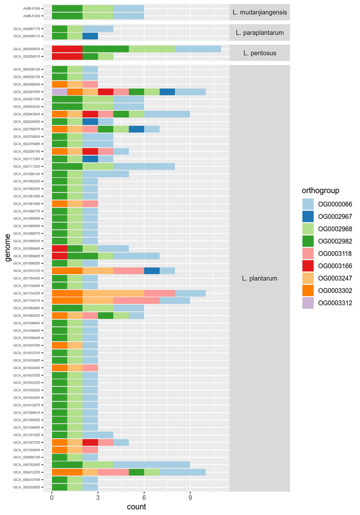

```r
TXSScan_genes %>%
  ggplot(aes(x = genome, fill = orthogroup)) +
  geom_bar() +
  coord_flip() +
  scale_fill_brewer(palette = "Paired") +
  facet_grid(cladeName~., scales = "free_y", space = "free_y") +
  theme(strip.text.y =  element_text(angle = 0),
        axis.text.y = element_text(size = 5))
```

How many times is each Gene detected?

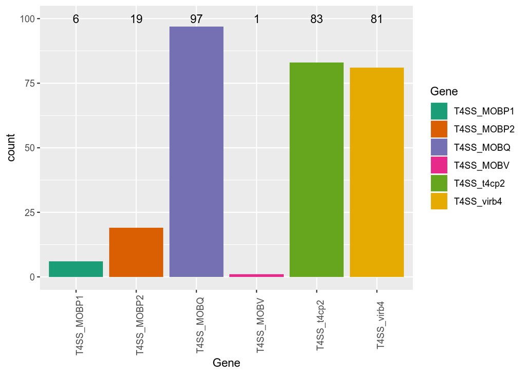

```r
TXSScan_genes %>%
  group_by(Gene) %>%
  summarise(count = n()) %>%
  ggplot(aes(x = Gene, y = count, fill = Gene)) +
  geom_col() +
  geom_text(aes(x = Gene, y = 100, label = count)) +
  scale_fill_brewer(palette = "Dark2") +
  theme(axis.text.x = element_text(angle = 90))
```

How many times is each orthogroup detected?

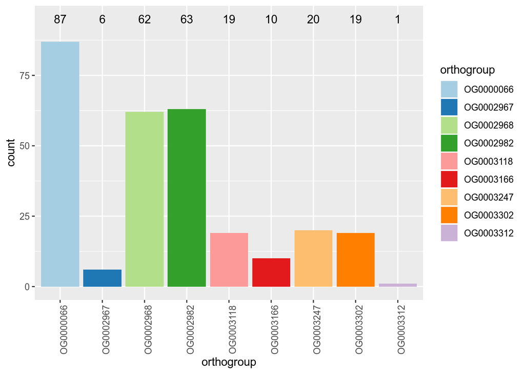

```r
TXSScan_genes %>%
  group_by(orthogroup) %>%
  summarise(count = n()) %>%
  ggplot(aes(x = orthogroup, y = count, fill = orthogroup)) +
  geom_col() +
  geom_text(aes(x = orthogroup, y = 95, label = count)) +
  scale_fill_brewer(palette = "Paired") +
  theme(axis.text.x = element_text(angle = 90))
```

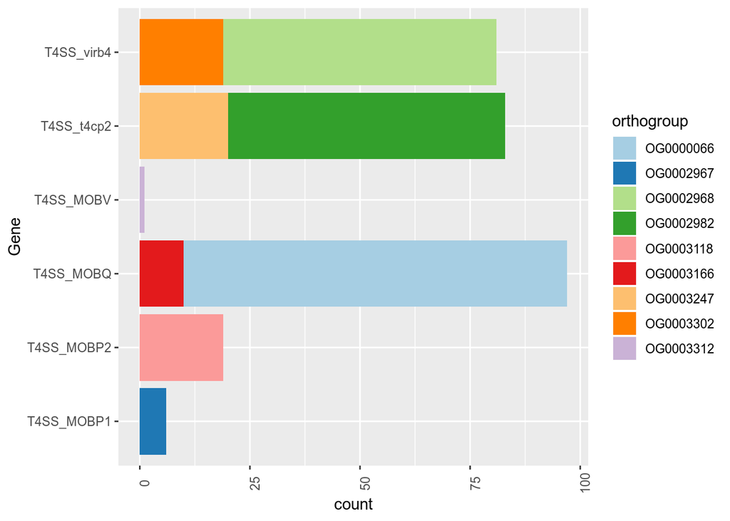

```r
TXSScan_genes %>%
  ggplot(aes(x = Gene, fill = orthogroup)) +
  geom_bar() +
  scale_fill_brewer(palette = "Paired") +
  theme(axis.text.x = element_text(angle = 90)) +
  coord_flip()
```

Okay, this is interesting!!! Apparantly the virb4 system is divided over 2 orthogroups. These are probably the genomes that have multiple hits in one genome. The same goes for T4cp2 and MOBQ(relaxases)!

In addition, OG0000066 seems like a a core orthogroup as it has a low number. Most genomes seem to have multiple copies in that orthogroup. That’s because most of them are annotated as nickase, so it could just capture all of them, but only these reported here are seen as real hits.

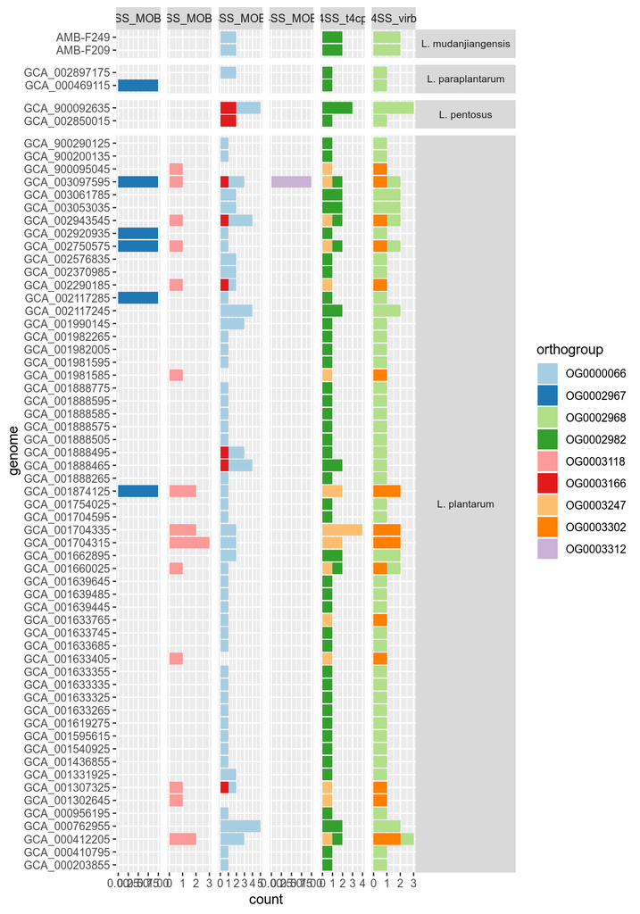

```r
TXSScan_genes %>%
  ggplot() +
  geom_bar(aes(x = genome, fill = orthogroup)) +
  facet_grid(cladeName~ Gene, scales = "free", space = "free_y") +
  coord_flip() +
  theme(strip.text.y =  element_text(angle = 0, size = 8)) +
  scale_fill_brewer(palette = "Paired")
```

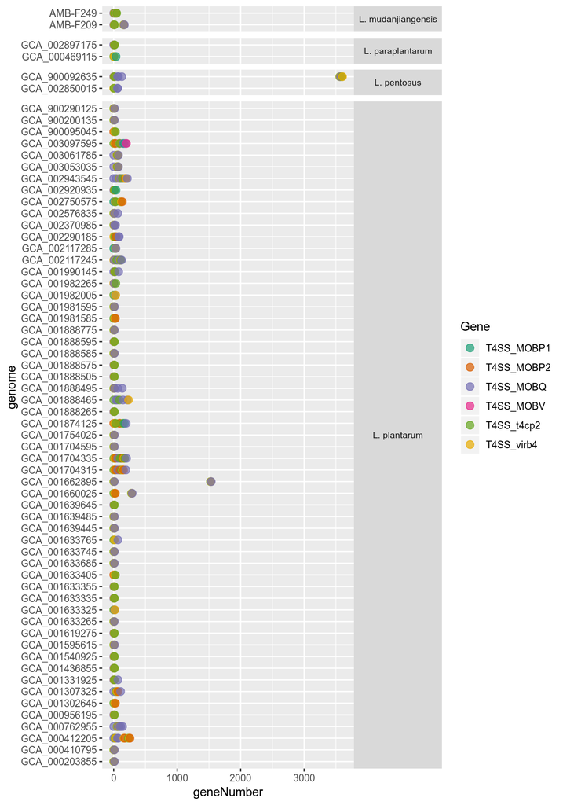

```r
TXSScan_genes %>%
  separate(gene, into = c("genome_id", "geneNumber")) %>%
  mutate(geneNumber = as.numeric(geneNumber)) %>%
  group_by(genome) %>%
  mutate(geneNumber = geneNumber - min(geneNumber)) %>%
  ggplot(aes(x = geneNumber, y = genome, color = Gene)) +
  geom_point(size = 3, alpha = 0.7) +
  facet_grid(cladeName~., scales = "free", space = "free_y") +
  theme(strip.text.y =  element_text(angle = 0, size = 8)) +
  scale_color_brewer(palette = "Dark2")
```

# Conclusion

The found hits are clearly connected with the conjugation system. Let’s run CONJScan!